# Peer Graded

Moses Otieno

18/12/2020

## Introduction

One thing that people regularly do is quantify how much of a particular activity they do, but they rarely quantify how well they do it. In this project, my goal will be to use data from accelerometers on the belt, forearm, arm, and dumbbell of 6 participants to predict the manner in which the participants did the exercise. I will describe how the model was built, how the cross validation was used, the expected sample error and the reasons the choices made were actually made.  
The outcome variable in the dataset is **classe**.

```r
urltrain <- "https://d396qusza40orc.cloudfront.net/predmachlearn/pml-training.csv"
urltest <- "https://d396qusza40orc.cloudfront.net/predmachlearn/pml-testing.csv"

#Check if the files have been downloaded. If not then download if yes load them


if(!file.exists("data/train.csv")){
download.file(urltrain, destfile = "data/train.csv")
} else{
  pml_training <- read_csv("data/train.csv")

}


if(!file.exists("data/test.csv")){
download.file(urltest, destfile = "data/test.csv")
} else{
  pml_testing <- read_csv("data/test.csv")

}
```

## Data management and preparation

```r
#glimpse(pml_training)

# Remove completely missing variables
pml_train_clean <- remove_empty(pml_training, "cols")

# Remove variables that are missing 97% of the time

varmiss <- as_vector(skim(pml_train_clean) %>%
  filter(complete_rate < 0.03) %>%
  select(skim_variable))



pml_train_clean <- pml_train_clean %>%
  select(!all_of(varmiss))

# Summary of the data

#summary(pml_train_clean)

# # Variable conversion
# pml_train_clean %>%
#   select_if(is.character)


# Convert classe to factor

pml_train_clean <- pml_train_clean %>%
  mutate(classe = as_factor(classe))

pml_testing_clean <- remove_empty(pml_testing, "cols") %>%
  select(!any_of(varmiss))


# Remove the identification variables
pml_train_clean <- pml_train_clean %>%
  select(-c(1:5))


# Remove the variables with same values in the entire dataset(near zero variance)

narz <- nearZeroVar(pml_train_clean)
pml_train_clean <- pml_train_clean[, -narz]
```

## Splitting the Data

We split the dataset into training and validation set in the ratio 7:3.

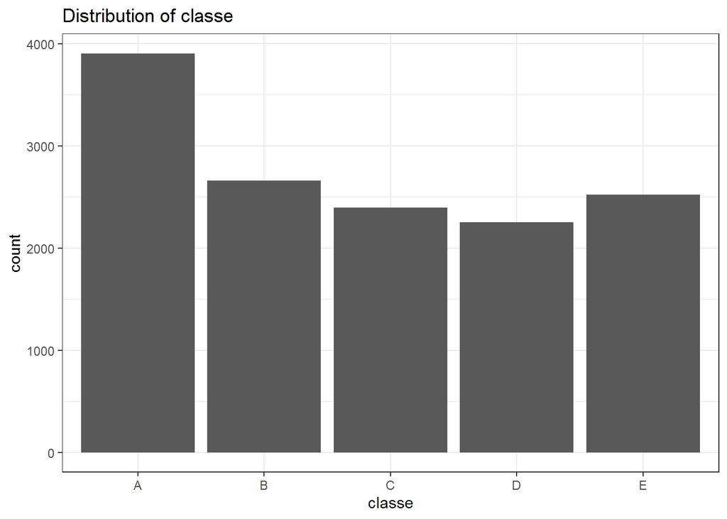

```r
# Set seed

set.seed(22122020)

inTrain <- createDataPartition(pml_train_clean$classe, p=0.7, list = F)
TrainingSet <- pml_train_clean[inTrain, ]
TestingSet <- pml_train_clean[-inTrain, ]


# A simple bar plot of classe variable

ggplot(TrainingSet, aes(classe)) +
  geom_bar() +
  labs(title = "Distribution of classe") +
  theme_bw()
```

Our training set consists of 13737 rows and 54 features while the testing set consists of 5885 rows and 54 features.

## Model Building

We will fit two models and compare between the two the best model based on predictive accuracy. The models to be fit are

- Decision Tree Model
- Random Forest Model

### Decision Tree Model

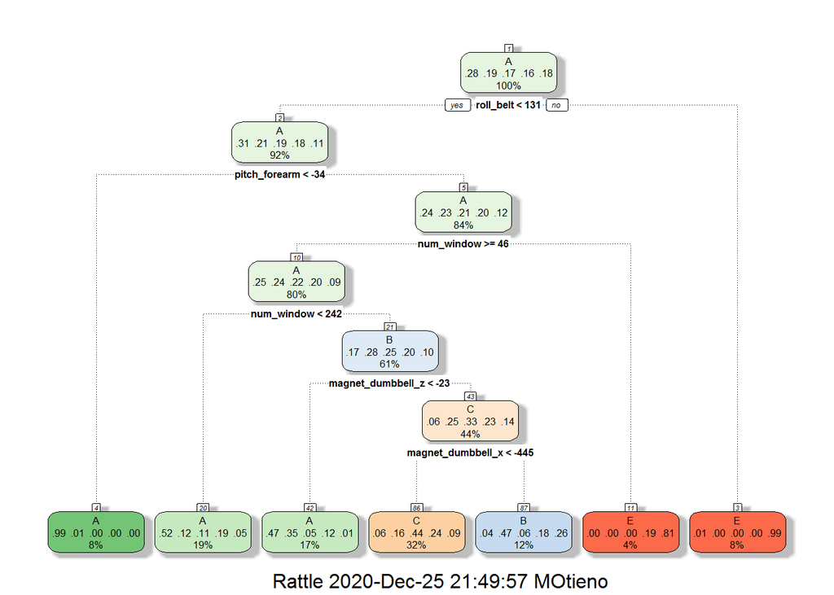

```r
# fit the model
set.seed(22122020)
fitControl <- trainControl(method="cv", number=10)

fit_tree <- train(classe ~ ., data = TrainingSet, method="rpart",
                  trControl = fitControl)

# fancy R Plot
fancyRpartPlot(fit_tree$finalModel)
```

```r
# prediction
predict_fit_tree <- predict(fit_tree, newdata = TestingSet, method="rpart")

#Confusion matrix

cmatrix <- confusionMatrix(predict_fit_tree,TestingSet$classe)
cmatrix
```

```
## Confusion Matrix and Statistics
##
##           Reference
## Prediction    A    B    C    D    E
##          A 1514  493  166  328   69
##          B   37  362   54  132  206
##          C  121  284  806  456  134
##          D    0    0    0    0    0
##          E    2    0    0   48  673
##
## Overall Statistics
##
##                Accuracy : 0.5701
##                  95% CI : (0.5573, 0.5828)
##     No Information Rate : 0.2845
##     P-Value [Acc > NIR] : < 2.2e-16
##
##                   Kappa : 0.4444
##
##  Mcnemar's Test P-Value : < 2.2e-16
##
## Statistics by Class:
##
##                      Class: A Class: B Class: C Class: D Class: E
## Sensitivity            0.9044  0.31782   0.7856   0.0000   0.6220
## Specificity            0.7492  0.90961   0.7952   1.0000   0.9896
## Pos Pred Value         0.5891  0.45765   0.4475      NaN   0.9308
## Neg Pred Value         0.9517  0.84747   0.9461   0.8362   0.9208
## Prevalence             0.2845  0.19354   0.1743   0.1638   0.1839
## Detection Rate         0.2573  0.06151   0.1370   0.0000   0.1144
## Detection Prevalence   0.4367  0.13441   0.3060   0.0000   0.1229
## Balanced Accuracy      0.8268  0.61372   0.7904   0.5000   0.8058
```

The predictive accuracy of decision tree model is 57.01%

### Random Forest Model

```r
# fit the model
set.seed(22122020)

controlRF <- trainControl(method="cv", number=3, verboseIter=FALSE)

fit_RF <- train(classe ~ ., data=TrainingSet, method="rf",
                          trControl=controlRF)

# Prediction

predict_RF <- predict(fit_RF, newdata = TestingSet)

# Confusion matrix

cmatrix_RF <- confusionMatrix(predict_RF, TestingSet$classe)
cmatrix_RF
```

```
## Confusion Matrix and Statistics
##
##           Reference
## Prediction    A    B    C    D    E
##          A 1674    2    0    0    0
##          B    0 1135    2    0    0
##          C    0    2 1024    3    0
##          D    0    0    0  961    1
##          E    0    0    0    0 1081
##
## Overall Statistics
##
##                Accuracy : 0.9983
##                  95% CI : (0.9969, 0.9992)
##     No Information Rate : 0.2845
##     P-Value [Acc > NIR] : < 2.2e-16
##
##                   Kappa : 0.9979
##
##  Mcnemar's Test P-Value : NA
##
## Statistics by Class:
##
##                      Class: A Class: B Class: C Class: D Class: E
## Sensitivity            1.0000   0.9965   0.9981   0.9969   0.9991
## Specificity            0.9995   0.9996   0.9990   0.9998   1.0000
## Pos Pred Value         0.9988   0.9982   0.9951   0.9990   1.0000
## Neg Pred Value         1.0000   0.9992   0.9996   0.9994   0.9998
## Prevalence             0.2845   0.1935   0.1743   0.1638   0.1839
## Detection Rate         0.2845   0.1929   0.1740   0.1633   0.1837
## Detection Prevalence   0.2848   0.1932   0.1749   0.1635   0.1837
## Balanced Accuracy      0.9998   0.9980   0.9985   0.9983   0.9995
```

## Inspect Cross Validation and Out of Sample Error

Mean accuracy of decision tree model is 0.52 and the standard deviation is 0.06.

Mean accuracy of random forest model is 1 and the standard deviation is 0.

Since the random forest proves to do a better job than the decision tree model, we use it in our prediction.

## Best Pedictive Model to test data

```r
predict_test <- tibble(predict(fit_RF, newdata = pml_testing))
predict_test
```

```
## # A tibble: 20 x 1
##    `predict(fit_RF, newdata = pml_testing)`
##    <fct>
##  1 B
##  2 A
##  3 B
##  4 A
##  5 A
##  6 E
##  7 D
##  8 B
##  9 A
## 10 A
## 11 B
## 12 C
## 13 B
## 14 A
## 15 E
## 16 E
## 17 A
## 18 B
## 19 B
## 20 B
```

```r
cat("Predictions: ", paste(predict(fit_RF, newdata = pml_testing)))
```

```
## Predictions:  B A B A A E D B A A B C B A E E A B B B
```